# mutect2 variant call report for: both

C. Savonen - CCDL for ALSF

2019-10-30

### Options used for report

```
## Options:
##  --label : mutect2
##  --plot_type : .png
##  --vaf : /home/rstudio/kitematic/OpenPBTA-analysis/analyses/snv-callers/results/mutect2
##  --file_format : rds
##  --output : /home/rstudio/kitematic/OpenPBTA-analysis/analyses/snv-callers/plots/mutect2
##  --strategy : wgs
##  --cosmic : wxs
##  --overwrite : both
##  --no_region : analyses/snv-callers/ref_files/brain_cosmic_variants_coordinates.tsv
##  --help : FALSE
##  --label : FALSE
##  --plot_type : FALSE
```

## Base call barplot

To evaluate base changes standard MAF fields were summarized as two new variables: The `base_change` variable indicates the exact change in bases from concatenating `Reference_Allele`, `>`, and `Allele`. The `change` variable is made from the `base_change` variable but groups together deletions, insertions, and long (more than a SNV) as their own groups.

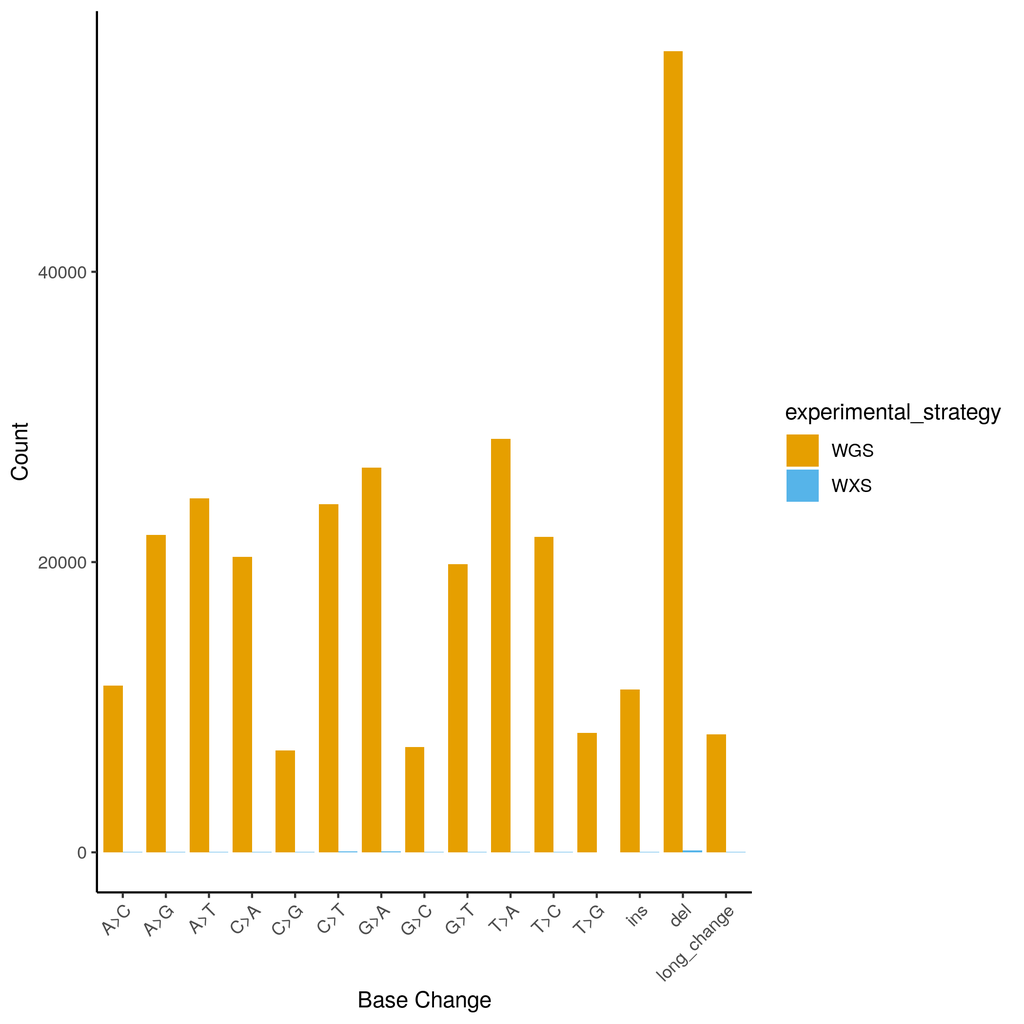

## Read depth and VAF

Compare read depth and VAF calculations.

```
vaf = (t_alt_count) / (t_ref_count + t_alt_count)
```

This is following the [code used in `maftools`](https://github.com/PoisonAlien/maftools/blob/1d0270e35c2e0f49309eba08b62343ac0db10560/R/plot_vaf.R#L39). The VAF calculations and other special variables are added to the MAF fields and written to a TSV ending in `_vaf.tsv` in the caller’s results folder.

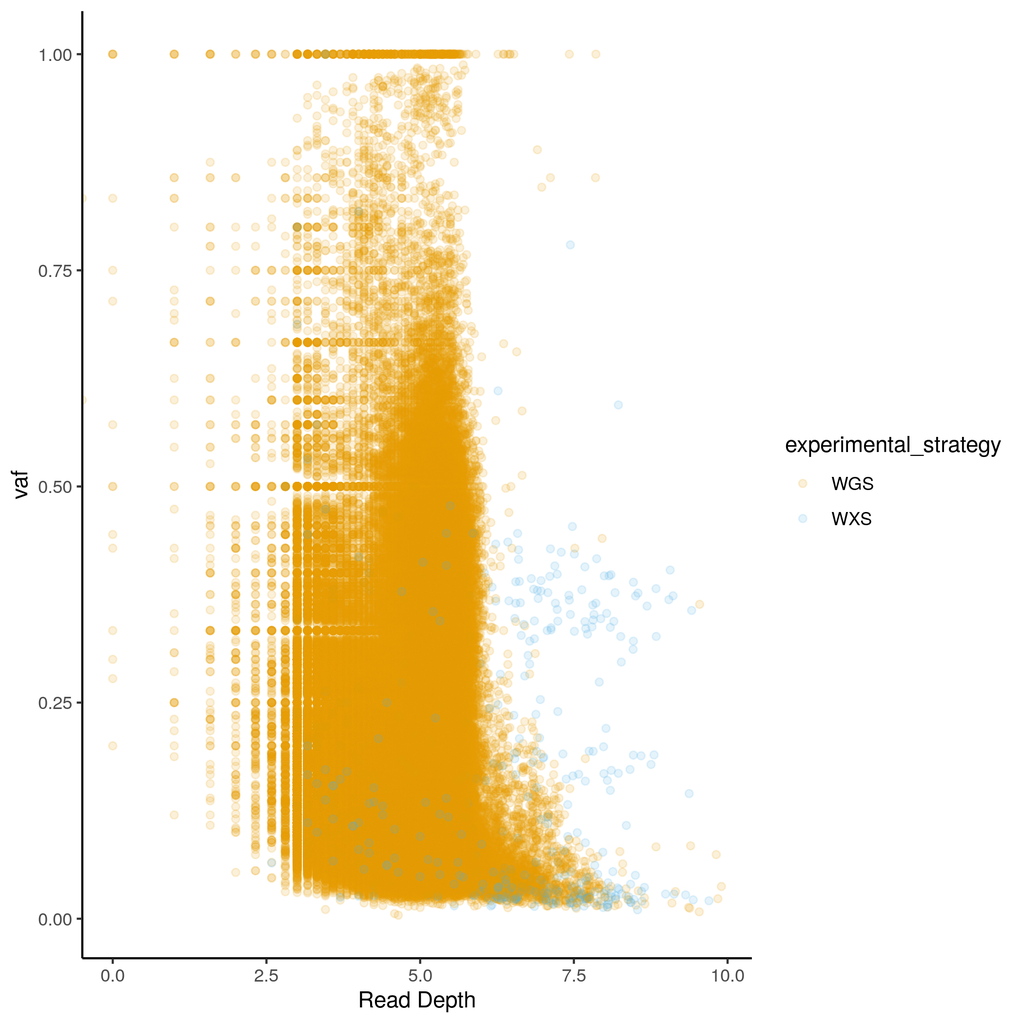

## Percent variants in COSMIC

The [COSMIC mutation data](https://cancer.sanger.ac.uk/cosmic/download) used here are the full, unfiltered somatic mutations from `CosmicMutantExport.tsv`, grch38. COSMIC mutations are overlapped with the present data’s mutations using `GenomicRanges`. The mutations that overlap with COSMIC mutations are plotted here.

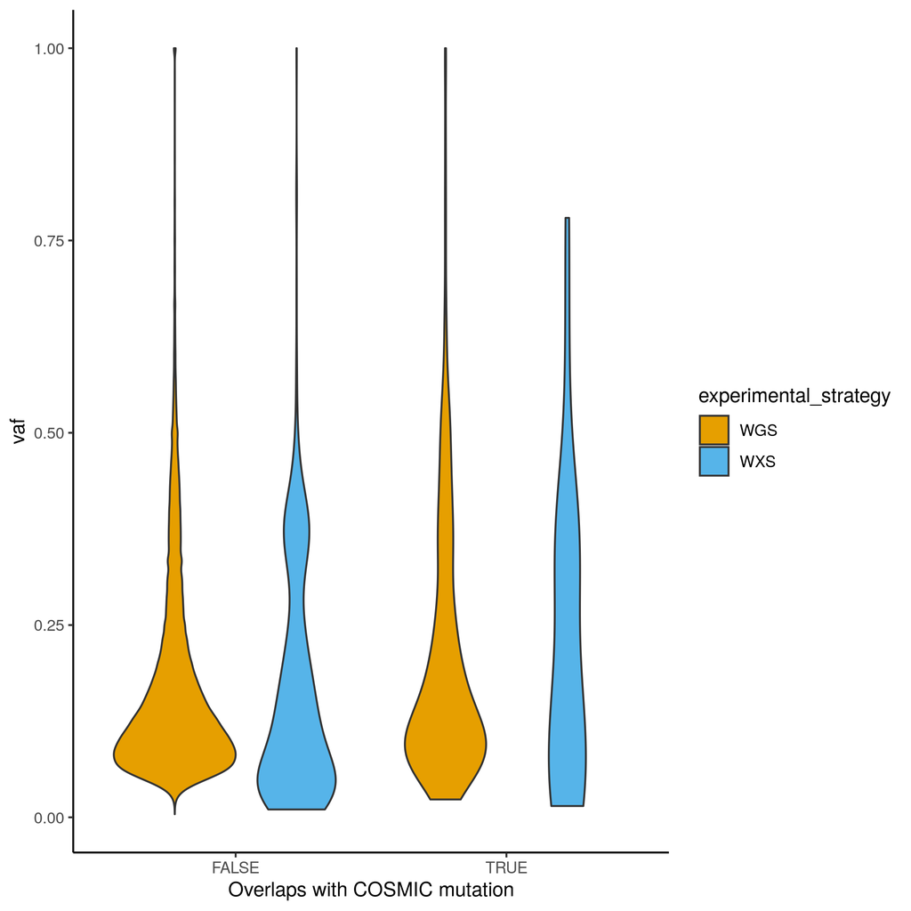

## TMB by histology

To calculate TMB, the sum of the bases (in Mb) included in the WXS or WGS BED regions are used as the denominator, depending on the sample’s processing strategy.

```
TMBwxs = sum(mutation_w-in_bedwxs)/(wxs_genome_size/1000000)
TMBwgs = sum(all_mutations)/(wgs_genome_size/1000000)
```

BED regions used for WGS samples are caller specific, while the WXS samples are calculated using the same BED file for all.

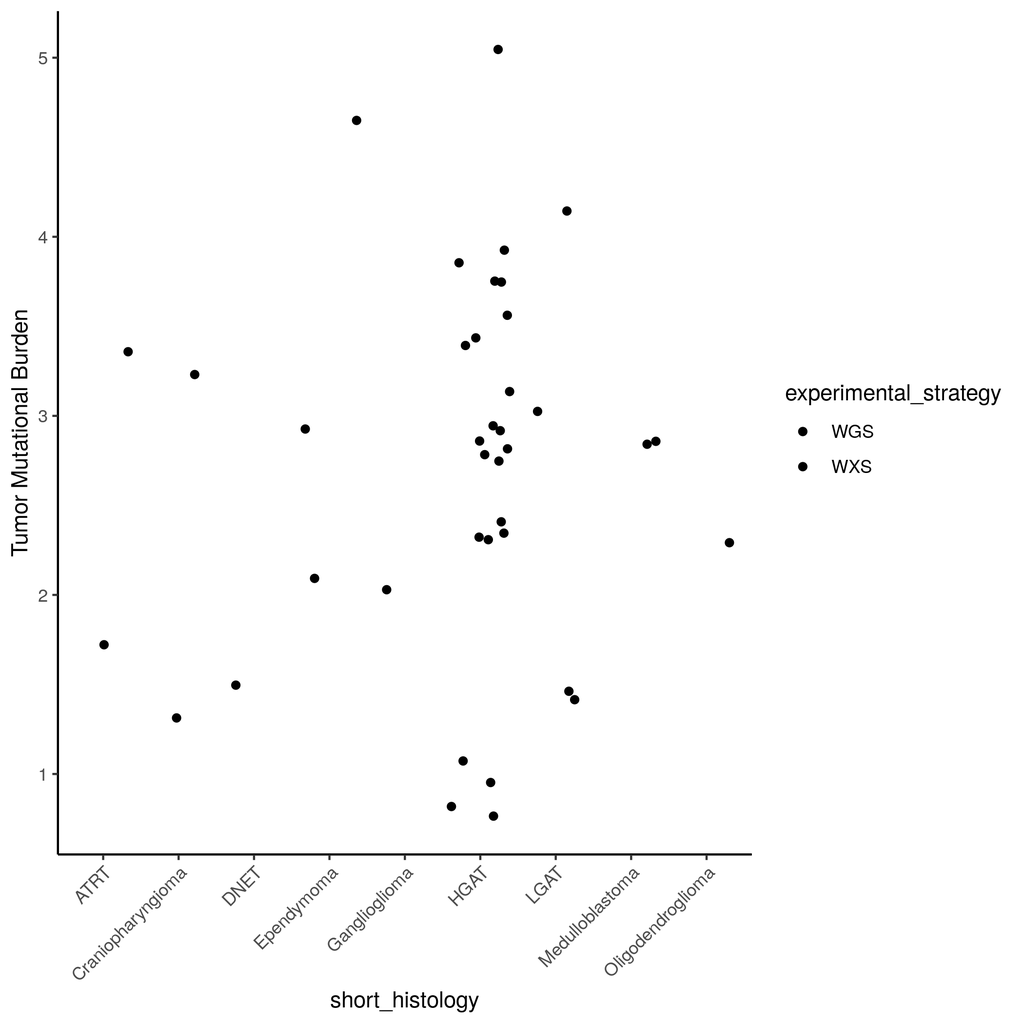